# Examining the Relationship Between Migration, Climate Disasters, and Economic Indicators Worldwide

## 95791 Section A2 Final Project

#### Michaela Marincic (mmarinci)

#### Daniel Picard (dpicard)

#### Philippe Schicker (pschicke)

## Introduction

Our project involves the impacts of climate change on migration and country's economic stability. In particular, we are looking to answer these questions:

- Which countries likely to experience immigration vs emigration based on the prevalence of different climate disasters and economic indicators? (Classification)
- Does net ODA (Official Development Assistance) increase with increasing disaster frequency and severity? (I.e. are countries receiving the assistance they need to recover from climate disasters?) (Regression)
- How does GDP change in response to migration and climate disasters? (Regression)

The datasets we are using for the project are:

1. GDIS Geocoded Disasters Dataset (https://sedac.ciesin.columbia.edu/data/set/pend-gdis-1960-2018/data-download)

Rosvold, E. and H. Buhaug. 2021. Geocoded disaster (GDIS) dataset. Palisades, NY: NASA Socioeconomic Data and Applications Center (SEDAC). https://doi.org/10.7927/zz3b-8y61. Accessed 30th Nov 2021.

1. World Bank migration data (https://databank.worldbank.org/source/world-development-indicators)
- As discussed in class, we are attaching the migration dataset as a CSV file to the submission in canvas. Since the original dataset link was moved, this link allows the user to create their own dataset with selected countries, economic indicators, and years. In order for you not to have to do that, we are including the CSV file.

In order to build the models for the final deliverable, we have cleaned the datasets and merged them into one.

## Cleaning Disasters Data

First we drop unnecessary columns from the data.

Then we drop any potential duplicates based on the unique disaster identification code ('id') and examine the resulting dataset.

Next we made a new variable to indicate the number of years since 1992, the first year in the dataset. This will help to bring the 'year' variable onto a smaller scale that is more comparable to most of the other variables.

Then we retain only those years that match the years included in our migration and economic data (every five years starting with 1992).

```python
migration_years = [1992, 1997, 2002, 2007, 2012, 2017]

# Filter to keep only data from the same years as the migration dataset.
disasters_copy = disasters_copy[disasters_copy['year'].isin(migration_years)]
disasters_copy.head()
```

|  | id | country | year | disastertype | yrs_since_92 |
| --- | --- | --- | --- | --- | --- |
| 14 | 539 | Bangladesh | 1997 | storm | 5 |
| 26 | 635 | Bangladesh | 2012 | storm | 20 |
| 79 | 1111 | Chile | 2002 | flood | 10 |
| 86 | 1120 | Chile | 2007 | earthquake | 15 |
| 127 | 2520 | Haiti | 2002 | flood | 10 |

We separate the categorical 'disastertype' variable into dummies for each type of disaster recorded.

```python
# Create dummy variables for each disaster type.
disasters_copy = pd.get_dummies(data = disasters_copy, columns = ['disastertype'])
disasters_copy.head()
```

|  | id | country | year | yrs_since_92 | disastertype_drought | disastertype_earthquake | disastertype_extreme temperature | disastertype_flood | disastertype_landslide | disastertype_mass movement (dry) | disastertype_storm | disastertype_volcanic activity |
| --- | --- | --- | --- | --- | --- | --- | --- | --- | --- | --- | --- | --- |
| 14 | 539 | Bangladesh | 1997 | 5 | 0 | 0 | 0 | 0 | 0 | 0 | 1 | 0 |
| 26 | 635 | Bangladesh | 2012 | 20 | 0 | 0 | 0 | 0 | 0 | 0 | 1 | 0 |
| 79 | 1111 | Chile | 2002 | 10 | 0 | 0 | 0 | 1 | 0 | 0 | 0 | 0 |
| 86 | 1120 | Chile | 2007 | 15 | 0 | 1 | 0 | 0 | 0 | 0 | 0 | 0 |
| 127 | 2520 | Haiti | 2002 | 10 | 0 | 0 | 0 | 1 | 0 | 0 | 0 | 0 |

```python
disasters_final.head(15)
```

| country | year | id | Dis_Country | Dis_Year | yrs_since_92 | disastertype_drought | disastertype_earthquake | disastertype_extreme temperature | disastertype_flood | disastertype_landslide | disastertype_mass movement (dry) | disastertype_storm | disastertype_volcanic activity |
| --- | --- | --- | --- | --- | --- | --- | --- | --- | --- | --- | --- | --- | --- |
| Afghanistan | 1992 | 10 | Afghanistan | 1992 | 0 | 0.0 | 0.0 | 0.0 | 2.0 | 0.0 | 0.0 | 0.0 | 0.0 |
|  | 1997 | 6-Apr | Afghanistan | 1997 | 5 | 0.0 | 1.0 | 0.0 | 2.0 | 1.0 | 0.0 | 0.0 | 0.0 |
|  | 2002 | 29 | Afghanistan | 2002 | 10 | 0.0 | 3.0 | 0.0 | 4.0 | 1.0 | 0.0 | 0.0 | 0.0 |
|  | 2007 | 68 | Afghanistan | 2007 | 15 | 0.0 | 0.0 | 0.0 | 7.0 | 0.0 | 0.0 | 0.0 | 0.0 |
|  | 2012 | 83 | Afghanistan | 2012 | 20 | 0.0 | 1.0 | 1.0 | 6.0 | 3.0 | 0.0 | 0.0 | 0.0 |
|  | 2017 | 5-Feb | Afghanistan | 2017 | 25 | 0.0 | 0.0 | 0.0 | 1.0 | 2.0 | 0.0 | 2.0 | 0.0 |
| Albania | 1992 | 98 | Albania | 1992 | 0 | 0.0 | 0.0 | 0.0 | 1.0 | 0.0 | 0.0 | 0.0 | 0.0 |
|  | 1997 | 101 | Albania | 1997 | 5 | 0.0 | 0.0 | 0.0 | 1.0 | 0.0 | 0.0 | 0.0 | 0.0 |
|  | 2002 | 104 | Albania | 2002 | 10 | 0.0 | 0.0 | 0.0 | 1.0 | 0.0 | 0.0 | 1.0 | 0.0 |
|  | 2007 | 10-Mar | Albania | 2007 | 15 | 0.0 | 0.0 | 1.0 | 0.0 | 0.0 | 0.0 | 0.0 | 0.0 |
|  | 2012 | 11-Mar | Albania | 2012 | 20 | 0.0 | 0.0 | 1.0 | 0.0 | 0.0 | 0.0 | 0.0 | 0.0 |
|  | 2017 | 12-Feb | Albania | 2017 | 25 | 0.0 | 0.0 | 1.0 | 1.0 | 0.0 | 0.0 | 0.0 | 0.0 |
| Algeria | 1992 | 125 | Algeria | 1992 | 0 | 0.0 | 1.0 | 0.0 | 1.0 | 0.0 | 0.0 | 0.0 | 0.0 |
|  | 1997 | 131 | Algeria | 1997 | 5 | 0.0 | 0.0 | 0.0 | 1.0 | 0.0 | 0.0 | 0.0 | 0.0 |
|  | 2002 | 140 | Algeria | 2002 | 10 | 0.0 | 0.0 | 0.0 | 3.0 | 0.0 | 0.0 | 0.0 | 0.0 |

## Cleaning the Migration and Economic Dataset

We create a 'rel.migration' variable that normalizes mirgration numbers based on the country's population. We also make dummy variables for each continent, clean up the variable names, and drop any data from before the time period under examination.

There are still a large number of null values, so we inspect which columns have the most nulls and how the nulls are distributed across the features. Finding that Net.ODA, Access.to.electricity, and Dem.Index had the most nulls, we considered whether these were necessary for the model and decided to remove them rather than compromise the remaining features.

All remaining features now have at least 1,000 non-null values, and the number of null values (514) is less than 3% of the remaining values, so we decided to drop the remaining null values at this point.

```python
migration2.head(15)
```

|  | Country.Name | Country.Code | Year | Net.migration | Agricultural.land.(%.of.land.area) | GDP.growth.(annual.%) | GDP.per.capita.(current.US$) | Mortality.rate.under.5.(per.1000.live.births) | Unemployment.total.(%.of.total.labor.force).(modeled.ILO.estimate) | Population.total | Battle.Deaths | Human.Rights | Hum.Dev | rel.migration | Continent.Africa | Continent.America | Continent.Asia | Continent.Europe | Continent.Oceania |
| --- | --- | --- | --- | --- | --- | --- | --- | --- | --- | --- | --- | --- | --- | --- | --- | --- | --- | --- | --- |
| 9 | Albania | ALB | 1992 | -443212 | 41.131387 | -7.187111 | 200.852220 | 37.8 | 16.33 | 3247039.0 | 0.0 | -0.062245 | 0.610 | -0.136497 | 0 | 0 | 0 | 1 | 0 |
| 12 | United Arab Emirates | ARE | 1992 | 368126 | 4.773303 | 3.344945 | 26420.872753 | 14.9 | 1.75 | 2052891.0 | 0.0 | 0.901811 | 0.727 | 0.179321 | 0 | 0 | 1 | 0 | 0 |
| 16 | Argentina | ARG | 1992 | -105000 | 46.682306 | 7.937292 | 6823.537616 | 27.3 | 6.36 | 33529326.0 | 0.0 | -0.168167 | 0.704 | -0.003132 | 0 | 1 | 0 | 0 | 0 |
| 19 | Armenia | ARM | 1992 | -496288 | 41.095890 | -41.800003 | 369.632617 | 44.7 | 1.80 | 3442817.0 | 85.0 | 0.197174 | 0.580 | -0.144152 | 0 | 0 | 1 | 0 | 0 |
| 26 | Australia | AUS | 1992 | 351078 | 60.659438 | 0.412185 | 18570.120462 | 8.2 | 10.73 | 17495000.0 | 0.0 | 1.309810 | 0.866 | 0.020067 | 0 | 0 | 0 | 0 | 1 |
| 30 | Austria | AUT | 1992 | 227841 | 36.485832 | 2.093525 | 24880.164118 | 8.6 | 3.59 | 7840709.0 | 0.0 | 1.373081 | 0.795 | 0.029059 | 0 | 0 | 0 | 1 | 0 |
| 34 | Burundi | BDI | 1992 | -320001 | 82.554517 | 1.009998 | 190.489014 | 177.7 | 1.79 | 5685565.0 | 333.0 | -1.966430 | 0.297 | -0.056283 | 1 | 0 | 0 | 0 | 0 |
| 38 | Belgium | BEL | 1992 | 106947 | 44.820232 | 1.530655 | 23372.619171 | 9.3 | 6.70 | 10045158.0 | 0.0 | 2.707606 | 0.806 | 0.010647 | 0 | 0 | 0 | 1 | 0 |
| 44 | Benin | BEN | 1992 | 68259 | 20.352962 | 2.957711 | 317.962855 | 166.7 | 1.51 | 5331803.0 | 0.0 | 1.147551 | 0.348 | 0.012802 | 1 | 0 | 0 | 0 | 0 |
| 50 | Bangladesh | BGD | 1992 | -813794 | 73.357917 | 5.442686 | 293.644998 | 131.9 | 2.27 | 107983704.0 | 96.0 | -1.758145 | 0.387 | -0.007536 | 0 | 0 | 1 | 0 | 0 |
| 55 | Bulgaria | BGR | 1992 | -356464 | 55.626864 | -7.272388 | 1211.980878 | 19.2 | 13.50 | 8540164.0 | 0.0 | -0.023302 | 0.691 | -0.041740 | 0 | 0 | 0 | 1 | 0 |
| 58 | Bahrain | BHR | 1992 | 5480 | 12.676056 | 6.689998 | 9082.758533 | 22.0 | 0.86 | 523086.0 | 0.0 | -0.230259 | 0.746 | 0.010476 | 0 | 0 | 1 | 0 | 0 |
| 68 | Belize | BLZ | 1992 | -9011 | 5.962297 | 12.059445 | 2666.881600 | 33.8 | 9.66 | 194324.0 | 0.0 | 1.654982 | 0.644 | -0.046371 | 0 | 1 | 0 | 0 | 0 |
| 72 | Bolivia | BOL | 1992 | -51670 | 33.075787 | 1.646497 | 788.151990 | 112.1 | 2.79 | 7160920.0 | 0.0 | -0.238213 | 0.536 | -0.007216 | 0 | 1 | 0 | 0 | 0 |
| 74 | Brazil | BRA | 1992 | 0 | 27.764598 | -0.466913 | 2596.919876 | 57.1 | 6.42 | 154259380.0 | 0.0 | -1.793874 | 0.611 | 0.000000 | 0 | 1 | 0 | 0 | 0 |

```python
merged.head(15)
```

|  | Country.Name | Country.Code | Year | Net.migration | Agricultural.land.(%.of.land.area) | GDP.growth.(annual.%) | GDP.per.capita.(current.US$) | Mortality.rate.under.5.(per.1000.live.births) | Unemployment.total.(%.of.total.labor.force).(modeled.ILO.estimate) | Population.total | ... | Dis_Year | yrs_since_92 | disastertype_drought | disastertype_earthquake | disastertype_extreme temperature | disastertype_flood | disastertype_landslide | disastertype_mass movement (dry) | disastertype_storm | disastertype_volcanic activity |
| --- | --- | --- | --- | --- | --- | --- | --- | --- | --- | --- | --- | --- | --- | --- | --- | --- | --- | --- | --- | --- | --- |
| 173 | Myanmar | MMR | 2002 | -1208092 | 16.716651 | 12.025513 | 142.082265 | 84.3 | 0.83 | 4.770217e+07 | ... | 2002 | 10 | 0.0 | 0.0 | 0.0 | 1.0 | 0.0 | 0.0 | 0.0 | 0.0 |
| 388 | Pakistan | PAK | 2012 | -1079167 | 46.781600 | 3.507033 | 1198.109001 | 82.9 | 1.70 | 1.872815e+08 | ... | 2012 | 20 | 0.0 | 0.0 | 0.0 | 3.0 | 2.0 | 0.0 | 0.0 | 0.0 |
| 34 | Papua New Guinea | PNG | 1992 | -21116 | 1.958663 | 13.849085 | 905.248981 | 81.4 | 2.82 | 4.836217e+06 | ... | 1992 | 0 | 0.0 | 0.0 | 0.0 | 1.0 | 0.0 | 0.0 | 0.0 | 1.0 |
| 289 | Philippines | PHL | 2007 | -1548077 | 39.541201 | 6.519292 | 1744.640313 | 33.1 | 3.43 | 8.940548e+07 | ... | 2007 | 15 | 1.0 | 0.0 | 0.0 | 5.0 | 0.0 | 0.0 | 8.0 | 1.0 |
| 36 | Russian Federation | RUS | 1992 | 2490121 | 13.522372 | -14.531074 | 3098.802639 | 21.7 | 5.18 | 1.485382e+08 | ... | 1992 | 0 | 0.0 | 0.0 | 0.0 | 1.0 | 1.0 | 0.0 | 0.0 | 0.0 |
| 297 | Sierra Leone | SLE | 2007 | 60000 | 50.203935 | 8.058145 | 360.372142 | 183.2 | 3.58 | 5.989633e+06 | ... | 2007 | 15 | 0.0 | 0.0 | 0.0 | 1.0 | 0.0 | 0.0 | 0.0 | 0.0 |
| 304 | Timor-Leste | TLS | 2007 | -38074 | 25.218561 | 10.228824 | 523.735517 | 72.1 | 3.14 | 1.036392e+06 | ... | 2007 | 15 | 1.0 | 0.0 | 0.0 | 2.0 | 0.0 | 0.0 | 0.0 | 0.0 |
| 301 | Togo | TGO | 2007 | -10598 | 64.258136 | -1.175120 | 449.144233 | 96.1 | 3.60 | 5.920359e+06 | ... | 2007 | 15 | 0.0 | 0.0 | 0.0 | 1.0 | 0.0 | 0.0 | 0.0 | 0.0 |
| 220 | Benin | BEN | 2007 | -48776 | 29.709117 | 5.986349 | 964.926944 | 117.6 | 0.82 | 8.454793e+06 | ... | 2007 | 15 | 0.0 | 0.0 | 0.0 | 1.0 | 0.0 | 0.0 | 0.0 | 0.0 |
| 123 | Bolivia | BOL | 2002 | -77720 | 34.441983 | 2.485565 | 904.226627 | 67.1 | 2.91 | 8.742814e+06 | ... | 2002 | 10 | 0.0 | 0.0 | 0.0 | 1.0 | 0.0 | 0.0 | 1.0 | 0.0 |
| 326 | Bolivia | BOL | 2012 | -57620 | 34.755839 | 5.122276 | 2609.880814 | 36.7 | 2.05 | 1.037768e+07 | ... | 2012 | 20 | 0.0 | 0.0 | 0.0 | 1.0 | 0.0 | 0.0 | 0.0 | 0.0 |
| 142 | Spain | ESP | 2002 | 2908209 | 58.951186 | 2.731022 | 17025.531983 | 5.1 | 11.15 | 4.143156e+07 | ... | 2002 | 10 | 0.0 | 0.0 | 0.0 | 1.0 | 0.0 | 0.0 | 0.0 | 0.0 |
| 230 | Central African Republic | CAF | 2007 | -125614 | 8.363029 | 4.607535 | 404.373965 | 157.9 | 4.17 | 4.198010e+06 | ... | 2007 | 15 | 0.0 | 0.0 | 0.0 | 1.0 | 0.0 | 0.0 | 0.0 | 0.0 |
| 59 | China | CHN | 1997 | -382999 | 55.571392 | 9.236780 | 781.744164 | 43.5 | 3.20 | 1.230075e+09 | ... | 1997 | 5 | 1.0 | 4.0 | 3.0 | 6.0 | 2.0 | 0.0 | 5.0 | 0.0 |
| 131 | Colombia | COL | 2002 | -231000 | 37.500676 | 2.503980 | 2396.627127 | 23.4 | 15.63 | 4.087536e+07 | ... | 2002 | 10 | 0.0 | 0.0 | 0.0 | 3.0 | 1.0 | 0.0 | 0.0 | 0.0 |

15 rows × 31 columns

## Initial Visualizations

#### Boxplot of Human Development (Hum. Dev.) Score across the years

The Hum. Dev. Score is an integral part of our analysis. By displaying the Hum. Dev. Score against years as a boxplot helps to identify potential outliers or differences across years.

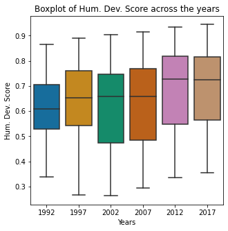

```python
plt.figure(figsize=(5,5))
sns.boxplot(y='Hum.Dev',
            x='Dis_Year',
            data=merged2,
            palette="colorblind")

plt.title("Boxplot of Hum. Dev. Score across the years")
plt.xlabel("Years")
plt.ylabel("Hum. Dev. Score")
plt.show()
```

#### Boxplot of Hum. Dev. Score across the years including migration trends

By displaying the Hum. Dev. Score against years while highlighting emigration (0) and immigration (1) as a boxplot helps to identify annual trends and differences across years.

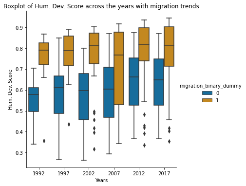

```python
sns.catplot(x="Dis_Year",
            y="Hum.Dev",
            hue="migration_binary_dummy",
            data=merged2,
            kind="box",
            palette="colorblind",
            height=5,
            aspect=1)

plt.title("Boxplot of Hum. Dev. Score across the years with migration trends")
plt.xlabel("Years")
plt.ylabel("Hum. Dev. Score")
plt.show()
```

#### Boxplot of Relative Migration by Number of Floods

We are hypothesizing that more severe weather will increase emigration, so we examine whether relative migration (net migration as a percent of the country's population) changes with the number of floods, since that was the most common disaster type.

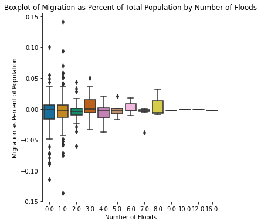

```python
sns.catplot(x="disastertype_flood",
            y="rel.migration",
            #hue="Dis_Year",
            data=merged2,
            kind="box",
            palette="colorblind",
            height=5,
            aspect=1)

plt.title("Boxplot of Migration as Percent of Total Population by Number of Floods")
plt.xlabel("Number of Floods")
plt.ylabel("Migration as Percent of Population")
plt.show()
```

#### Distribution plot of Hum. Dev. Score

Displaying the Hum. Dev. score distribution is valuable information. It is helpful in identifying potential outliers, determine if the data is normally distributed and other features that may not be seen without showing the data visually.

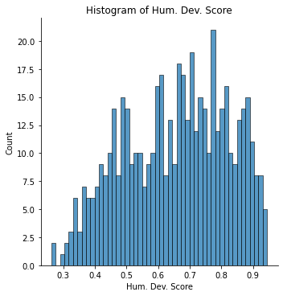

```python
sns.displot(merged2["Hum.Dev"],
            bins=50,
            height=5,
            aspect=1)

plt.title("Histogram of Hum. Dev. Score")
plt.xlabel("Hum. Dev. Score")
plt.show()
```

## Question 1 - Classify which countries will see immigration vs. emigration due to climate disasters.

### Q1 - Feature Selection

Before testing different models, we performed feature selection using the feature importance metrics from a Random Forest Classifier.

```python
# Build a Random Forest Classifier
rfc = RandomForestClassifier().fit(X_train, y_train)

# Create predictions to generate a confusion matrix and classification report
rfcpreds = rfc.predict(X_test)
print(classification_report(y_test, rfcpreds))
```

```
              precision    recall  f1-score   support

           0       0.87      0.98      0.92        84
           1       0.94      0.73      0.83        45

    accuracy                           0.89       129
   macro avg       0.91      0.85      0.87       129
weighted avg       0.90      0.89      0.89       129
```

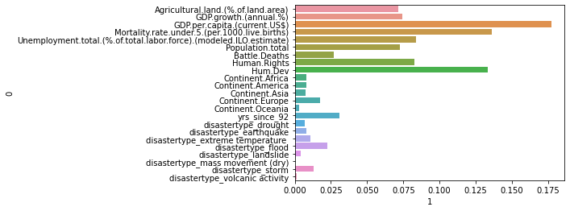

```python
#plot feature importance in a bar chart
sns.barplot(x=1, y=0, data=df)
```

### Q1 - Model One: K-Nearest Neighbors

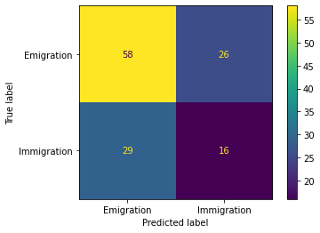

```
              precision    recall  f1-score   support

           0       0.67      0.69      0.68        84
           1       0.38      0.36      0.37        45

    accuracy                           0.57       129
   macro avg       0.52      0.52      0.52       129
weighted avg       0.57      0.57      0.57       129
```

```python
# Create and display a confusion matrix for the predictions compared to true values
knn_cm = confusion_matrix(y_test, knn_preds)
ConfusionMatrixDisplay(confusion_matrix = knn_cm, display_labels=['Emigration', 'Immigration']).plot()
plt.show()

# Print the classification report
print(classification_report(y_test, knn_preds))
```

### Q1 - KNN Cross Validation

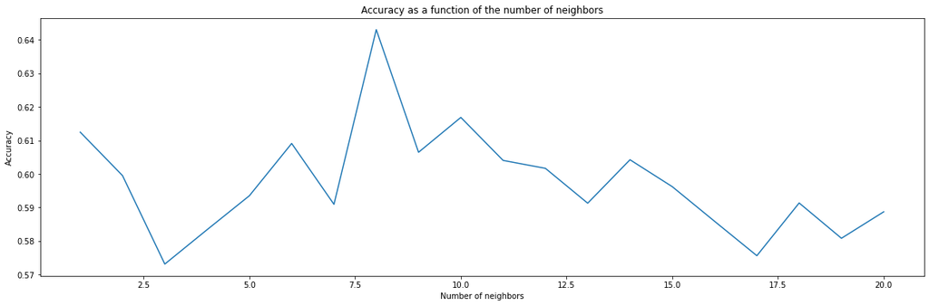

```python
# Set up parameters for the plot appearance.
plt.figure(figsize=(20, 6))
plt.subplot(111)
ax = plt.gca()

# Input X, y data
ax.plot(neighbors, CV)

# label the Axes and Title
plt.xlabel("Number of neighbors")
plt.ylabel("Accuracy")
plt.title("Accuracy as a function of the number of neighbors")
plt.axis("tight")

#Display the plot.
plt.show()
```

```python
print("Minimum CV error:", min(CV))
print("Number of neighbors at minimum CV:",CV.index(min(CV)) + 1)
```

```
Minimum CV error: 0.5731443994601889
Number of neighbors at minimum CV: 3
```

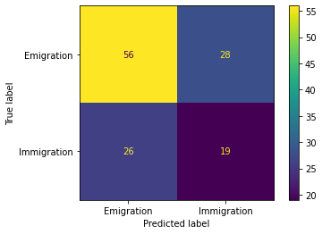

```python
# Build a KNN object with number of neighbors set to 4.
KNN = KNeighborsClassifier(n_neighbors=3)

# Fit the data to the KNN object.
KNN.fit(X_train2, y_train)

# Use the model to predict y values for the X_test data.
preds = KNN.predict(X_test2)

# Create a confusion matrix to compare the predicted y values to the actual y values from the test data.
conmat = confusion_matrix(y_test, preds)

# Display the confusion matrix.
ConfusionMatrixDisplay(confusion_matrix=conmat, display_labels = ['Emigration','Immigration']).plot()
plt.show()
```

```python
# Display a classification report with accuracy, recall, f1-score and precision values.
print(classification_report(y_test, preds))
```

```
              precision    recall  f1-score   support

           0       0.68      0.67      0.67        84
           1       0.40      0.42      0.41        45

    accuracy                           0.58       129
   macro avg       0.54      0.54      0.54       129
weighted avg       0.59      0.58      0.58       129
```

Unfortunately, even with cross-validation, the model's accuracy only improved by one percentage point. Precision, recall, and f1-score simiarly only improved by two percentage points. The model is still not a strong predictor of migration and performs only slightly better than a coin flip.

### Q1 - Model Two: Random Forest Classifier

```python
# Build a Random Forest Classifier
rfc = RandomForestClassifier().fit(X_train2, y_train)

# Create predictions to generate a confusion matrix and classification report
rfcpreds = rfc.predict(X_test2)
print(classification_report(y_test, rfcpreds))
```

```
              precision    recall  f1-score   support

           0       0.85      0.98      0.91        84
           1       0.94      0.69      0.79        45

    accuracy                           0.88       129
   macro avg       0.90      0.83      0.85       129
weighted avg       0.88      0.88      0.87       129
```

```python
# Set the parameters and model
parameters = {'n_estimators': range(20,401,40),
              'max_depth': range(5,9),
              'min_samples_split':range(6,11)}
model = RandomForestClassifier(random_state=1)

# Tune the parameters using GridSearchCV
GS_CV = GridSearchCV(estimator=model, param_grid=parameters)
```

```
              precision    recall  f1-score   support

           0       0.86      0.98      0.92        84
           1       0.94      0.71      0.81        45

    accuracy                           0.88       129
   macro avg       0.90      0.84      0.86       129
weighted avg       0.89      0.88      0.88       129
```

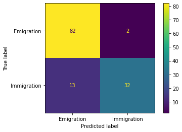

```python
# Build a Random Forest Classifier
rfc = RandomForestClassifier(max_depth=8, min_samples_split=6, n_estimators=100, random_state=1).fit(X_train2, y_train)

# Create predictions to generate a confusion matrix and classification report
rfcpreds = rfc.predict(X_test2)
conmat_rfc = confusion_matrix(y_test, rfcpreds)
ConfusionMatrixDisplay(confusion_matrix = conmat_rfc, display_labels = ['Emigration','Immigration']).plot()
print(classification_report(y_test, rfcpreds))
```

### Q1 - Model Three: Gaussian Naive Bayes

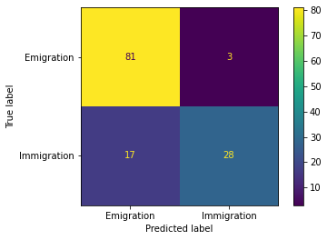

```python
# Create a Gaussian Naive Bayes object.
nb = GaussianNB()

# Fit the training data to the model and then use the model to predict the y values for the X_test data.
preds = nb.fit(X_train2, y_train).predict(X_test2)

# Create a confusion matrix to compare the predicted y values to the actual y values from the test data.
cm_nb = confusion_matrix(y_test, preds)

# Display the confusion matrix.
ConfusionMatrixDisplay(confusion_matrix = cm_nb, display_labels = ['Emigration','Immigration']).plot()
plt.show()
```

```python
# Display a classification report with accuracy, recall, f1-score and precision values.
print(classification_report(y_test, preds))
```

```
              precision    recall  f1-score   support

           0       0.83      0.96      0.89        84
           1       0.90      0.62      0.74        45

    accuracy                           0.84       129
   macro avg       0.86      0.79      0.81       129
weighted avg       0.85      0.84      0.84       129
```

## Question 2 - Predicting whether net ODA is increasing with increasing disaster frequency

### Q2 - Fitting Three Regression Models: Ridge, Lasso and Linear

```python
#Fit and tune Ridge regression model
ridge = RidgeCV(cv=10, alphas=np.logspace(-5,5,200), normalize=True).fit(Xo_train, yo_train)
```

```python
#Fit and tune Lasso regression model
lasso = LassoCV(cv=10, alphas=np.logspace(-5,5,200), normalize=True).fit(Xo_train, yo_train)
```

```python
#Fit Linear regression model
lm = LinearRegression(normalize=True).fit(Xo_train, yo_train)
```

We also check to see whether to transform the linear model to polynomial by examining the training and testing MSE for degrees 1 through 5.

```python
for i in range(1,6): #Check for optimal degree
    lr = LinearRegression(normalize=True) #New LinearRegression object
    p = PolynomialFeatures(degree=i) #PolynomialFeatures object for degree in question
    X_train_new = p.fit_transform(Xo_train) #Transform the training set to incorporate n-degree polynomials
    X_test_new = p.fit_transform(Xo_test) #Transform the test set to incorporate n-degree polynomials
    lr.fit(X_train_new, yo_train) #Fit n-degree model
    y_pred_train = lr.predict(X_train_new) #Generate predicted values for new training set
    y_pred_test = lr.predict(X_test_new) #Generate predicted values for new test set

    print('Training MSE for degree', i, ': ', mean_squared_error(yo_train, y_pred_train))
    print('Testing  MSE for degree', i, ': ', mean_squared_error(yo_test, y_pred_test))
    print('\n')
```

```
Training MSE for degree 1 :  57.35473096691444
Testing  MSE for degree 1 :  35.20480782832995


Training MSE for degree 2 :  112.99236386339477
Testing  MSE for degree 2 :  1.9072196739679494e+26


Training MSE for degree 3 :  2.1413337695359942e-26
Testing  MSE for degree 3 :  12708.831726368859


Training MSE for degree 4 :  1.8917684489855637e-26
Testing  MSE for degree 4 :  23337.802726343132


Training MSE for degree 5 :  8.042996333108086e-26
Testing  MSE for degree 5 :  35715.24400034631
```

### Q2 - Cross Validation

```python
print('CV error with Ridge regression', CV_Ridge*(-1))
print('CV error with Lasso regression', CV_Lasso*(-1))
print('CV error with linear regression', CV_Lin*(-1))
```

```
CV error with Ridge regression 78.21747391286434
CV error with Lasso regression 75.11573693035584
CV error with linear regression 85.59109010276474
```

Since the Lasso regression has the lowest CV error, it is the most predictive of net ODA. We will use it for the analysis.

## Question 3 - Impact on GDP of Migration and Climate Disasters

```python
#Linear Regression
lm = LinearRegression(normalize=True)

#Fit LR on training data
lm.fit(X_train, y_train)

#Use LR to predict trainig & testing test observations
y_pred_train = lm.predict(X_train)
y_pred_test = lm.predict(X_test)

#Printing out R-squared & MSEs
print("Training R-squared: ",round(lm.score(X_train, y_train), 4))
print("Testing R-squared:  ",round(lm.score(X_test, y_test), 4))
print()

print("Training MSE:       ",round(mean_squared_error(y_train, y_pred_train), 4))
print("Test MSE:           ",round(mean_squared_error(y_test, y_pred_test), 4))
```

```
Training R-squared:  0.7223
Testing R-squared:   0.613

Training MSE:        53080444.3807
Test MSE:            62122409.7444
```

#### Linear Regression with CV

- Iterating through all possible number of features
- Calculating Avg CV errors for each
- Selecting min Error

Through feature selection, we can identify the optimal number of predictors from the given ones for the smallest CV error and therefore identify the best model.

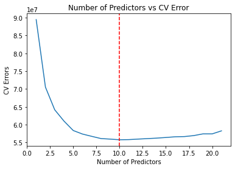

```
Number of Predictors that corresponds to the lowest CV Error: 10
Lowest CV Error: 55746842.3704
```

```python
#Plot Size
plt.figure(figsize=(20,6))

#Graphing Plot
plt.subplot(111)
ax = plt.gca()
ax.plot(predictors, cv_errors)
plt.xlabel("Number of Predictors")
plt.ylabel("CV Errors")
plt.title("Number of Predictors vs CV Error")

#Printing Vertical Line
plt.axvline(predictors[cv_errors.index(min_error)], color='r', linestyle='--')

plt.show()

#Printing #of Predictors & the corresponding min Error
print("Number of Predictors that corresponds to the lowest CV Error:", predictors[cv_errors.index(min_error)])
print("Lowest CV Error:", round(min_error, 4))
```

#### Ridge Regression

- Ridge Regression to perform feature selection.
- This will shrink the $\hat{\beta}$ coefficients close to zero.

```python
model_ridge_cv = RidgeCV(cv=10, alphas=np.logspace(-5,5,200), normalize=True).fit(X_train, y_train)
```

#### Lasso Regression

- Lasso Regression to perform feature selection.
- This will shrink the $\hat{\beta}$ coefficients to zero.

```python
model_lasso_cv = LassoCV(cv=10, alphas=np.logspace(-5,5,200), normalize=True).fit(X_train, y_train)
```

```python
#Printing Linear Regression
print("Linear Regression:")
print("Number of Predictors corresponding to the lowest CV Error:", predictors[cv_errors.index(min_error)])
print("Lin. Regression - Min Error:", round(min_error, 4))
print()

#Printing Ridge Regression
print("Ridge regression error:", ridge_error)

#Printing Lasso Regression
print("Lasso regression error:", lasso_error)
```

```
Linear Regression:
Number of Predictors corresponding to the lowest CV Error: 10
Lin. Regression - Min Error: 55746842.3704

Ridge regression error: 62478178.795810126
Lasso regression error: 57946067.341298535
```

## Conclusions

#### Which countries likely to experience immigration vs emigration based on the prevalence of different climate disasters and economic indicators?

```
<sklearn.metrics._plot.confusion_matrix.ConfusionMatrixDisplay at 0x131e28640>
```

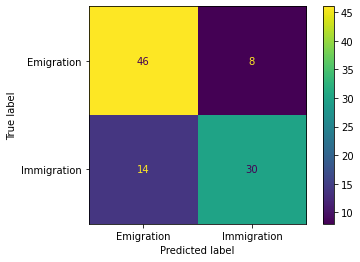

```python
conmat_rfc = confusion_matrix(y_2018, rfcpreds)
ConfusionMatrixDisplay(confusion_matrix = conmat_rfc, display_labels = ['Emigration','Immigration']).plot()
```

```python
print(classification_report(y_2018, rfcpreds))
```

```
              precision    recall  f1-score   support

           0       0.77      0.85      0.81        54
           1       0.79      0.68      0.73        44

    accuracy                           0.78        98
   macro avg       0.78      0.77      0.77        98
weighted avg       0.78      0.78      0.77        98
```

#### Does net ODA (Official Development Assistance) increase with increasing disaster frequency? (I.e. are countries receiving the assistance they need to recover from climate disasters?)

```python
for i in range(len(Xo_test.columns)):
    print(Xo_test.columns[i], 'coefficient: ', round(lasso.coef_[i],4))
```

```
Net.migration coefficient:  0.0
Agricultural.land.(%.of.land.area) coefficient:  -0.0033
GDP.growth.(annual.%) coefficient:  0.0
GDP.per.capita.(current.US$) coefficient:  -0.0
Mortality.rate.under.5.(per.1000.live.births) coefficient:  0.0
Unemployment.total.(%.of.total.labor.force).(modeled.ILO.estimate) coefficient:  -0.0
Population.total coefficient:  -0.0
Battle.Deaths coefficient:  0.0001
Human.Rights coefficient:  1.4644
Hum.Dev coefficient:  -32.5577
rel.migration coefficient:  -63.3843
Continent.Africa coefficient:  0.0
Continent.America coefficient:  -0.0
Continent.Asia coefficient:  -0.0
Continent.Europe coefficient:  2.6799
Continent.Oceania coefficient:  0.0
Dis_Year coefficient:  -0.0
yrs_since_92 coefficient:  -0.0
total_disasters coefficient:  0.0
```

#### How does GDP change in response to migration and climate disasters?

```python
for i in range(len(X2_test.columns)):
    print(X2_test.columns[i], 'coefficient: ', round(lm2.coef_[i],4))
```

```
Net.migration coefficient:  0.0037
Mortality.rate.under.5.(per.1000.live.births) coefficient:  167.0935
Unemployment.total.(%.of.total.labor.force).(modeled.ILO.estimate) coefficient:  -282.6829
Population.total coefficient:  0.0
Battle.Deaths coefficient:  0.1252
Human.Rights coefficient:  1932.1273
Hum.Dev coefficient:  88010.5605
Continent.America coefficient:  -2141.3707
disastertype_earthquake coefficient:  -1201.0135
disastertype_volcanic activity coefficient:  2402.2211
```

## Future Work

#### If we had more time:

- Acquire annual data to supplement the five-year increments used in this analysis
- Include more nuanced data for capturing climate impacts (e.g. harvest yields)

#### Improvements to the models:

- Attempt boosting on the Random Forest Classifier to improve performance

## Future Work

#### Paths we couldn’t take due to timing restrictions or data:

- Incorporating more climate data as predictors of migration and perhaps removing economic indicators, which could be overpowering any climate impacts

#### Constraints:

- Economic indicators, including GDP, are not always reliably measured throughout the world
- Only disasters of a certain scale were included in the disaster dataset (i.e. does not capture smaller extreme weather events)
- Certain disaster types were notably missing (e.g. hurricane, tornado, tsunami)
- Null values limited the size of the datasets, particularly for Question 2

## References

- https://chrisalbon.com/code/machine_learning/trees_and_forests/feature_selection_using_random_forest/
- https://pandas.pydata.org/docs/reference/api/pandas.DataFrame.sort_index.html
- https://stackoverflow.com/questions/54307300/what-causes-indexing-past-lexsort-depth-warning-in-pandas
- https://seaborn.pydata.org/generated/seaborn.heatmap.html
- https://seaborn.pydata.org/generated/seaborn.displot.html
- https://seaborn.pydata.org/generated/seaborn.boxplot.html
- https://seaborn.pydata.org/generated/seaborn.boxplot.html
- https://seaborn.pydata.org/generated/seaborn.boxplot.html
- https://pandas.pydata.org/docs/reference/api/pandas.DataFrame.merge.html
- https://pandas.pydata.org/docs/reference/api/pandas.DataFrame.drop_duplicates.html
- https://stackoverflow.com/questions/51459651/drop-duplicates-keeping-the-row-with-the-highest-value-in-another-column
- https://stackoverflow.com/questions/24502500/python-matplotlib-getting-rid-of-matplotlib-mpl-warning
- https://pandas.pydata.org/docs/reference/api/pandas.DataFrame.replace.html
- https://pandas.pydata.org/docs/reference/api/pandas.DataFrame.merge.html#pandas.DataFrame.merge
- https://stackoverflow.com/questions/13035764/remove-pandas-rows-with-duplicate-indices
- https://jakevdp.github.io/PythonDataScienceHandbook/03.05-hierarchical-indexing.html
- https://thispointer.com/pandas-sum-rows-in-dataframe-all-or-certain-rows/
- https://pandas.pydata.org/docs/reference/api/pandas.DataFrame.set_index.html
- https://www.geeksforgeeks.org/ways-to-filter-pandas-dataframe-by-column-values/
- https://pandas.pydata.org/docs/reference/api/pandas.get_dummies.html
- https://scikit-learn.org/stable/modules/generated/sklearn.linear_model.LinearRegression.html
- HW1, HW2, HW3, Lab1, Lab2, Lab3, Lab4 answers